# Extraction Project: MTBLS564 data Analysis

Mário Varela & Rui Pires

# 1 Introdução

- Osteoartrite (OA) é uma doença degenerativa que atua nas articulações. É caracterizada por perda de cartilagem na articulação, disfunção da membrana sinovial, esclerose óssea subcondral e formação de osteófitos com o desgaste de proteínas de matriz causadas por protéases. Artrite reumatoide (RA) é uma doença autoimune inflamatória sistémica que afeta o espaço sinovial das articulações. É caracterizada pela inflamação do espaço sinovial e destruição da cartilagem e do próprio osso. O líquido sinovial (SF) da artrite reumatoide apresenta elevadas concentrações de citoquininas, mediadores de inflamação e protéases [1].
- O SF encontra-se na cavidade da articulação e tem como principal função a lubrificação da mesma. Este líquido contém metabolitos e proteínas sistémicas capazes de sinalizar OA e RA. Além disso, por estar em contacto com tecidos que são os primeiros alvos destas patologias, apresenta potencial para a descoberta de biomarcadores cujos níveis de concentração são alterados nas fases iniciais da doença. O estudo em questão apresenta uma comparação direta entre os perfis metabólicos de SF em OA e RA utilizando espetroscopia H1 NMR, e introduz uma nova visão sobre a atividade metabólica nas articulações de pacientes com duas doenças de artrite muito comuns [1].
- Este estudo consiste numa análise por ressonância magnética nuclear (NMR) de SF de dois grupos de pacientes, um com OA e outro com RA, para avaliação da metabólica das doenças e otimização de protocolos para volumes relevantes de SF. Foram efetuados exames NMR aos perfis metabólicos completos de pequenos volumes de SF (100 µL) de ambos os grupos de pacientes. Os pacientes com OA apresentam uma média de idades de 67.4, encontram-se nos estados finais da doença e foram diagnosticados como isentos de RA. Os pacientes com RA apresentam idades semelhantes aos pacientes de OA, com um intervalo de 5 anos. Estes pacientes encontram-se sobre os efeitos da doença RA, em média, há 13 anos. Aquando a experiência, os pacientes com RA receberam vários tratamentos que incluíam medicamentos antirreumáticos (principalmente metotrexato) e inibidores de TNF como o etarnecept [1].

# 2 Recolha dos dados

- Os dados experimentais foram normalizados pela mediana e re-scaled pelo método de Pareto para posteriores análises multivariadas. Análises uni variadas foram feitas através de t-tests com um nível de confiança de 95%, enquanto análises multivariadas foram feitas por análise de componente principal (PCA) não supervisionado seguida de uma análise discriminante de mínimos quadrados parciais (PLS-DA). A análise referente às vias metabólicas foi feita usando a lista de metabolitos que apresentaram diferenças significativas entre os dois grupos de amostras como argumento para o Metaboanalyst, com referência à base de dados de vias metabólicas do KEGG (Kyoto Encyclopedia of Genes and Genomes)[5]. O esquema das vias metabólicas é representado pelo pathways plot.

# 3 FASE 1

## 3.1 PRÉ PROCESSAMENTO DOS DADOS

- R setup
- Packages setup and data reading

```r
sum_dataset(MTBLS564_bruker, stats=T)
```

```
## Dataset summary:
## Valid dataset
## Description:  1H NMR Metabolomics
## Type of data:  nmr-spectra
## Number of samples:  24
## Number of data points 17172
## Number of metadata variables:  1
## Number of missing values in data:  116
## Mean of data values:  337307.6
## Median of data values:  1020.758
## Standard deviation:  5089412
## Range of values:  -91123.31 187642535
## Quantiles:
##            0%           25%           50%           75%          100%
##    -91123.312      -453.500      1020.758      3277.281 187642534.625
```

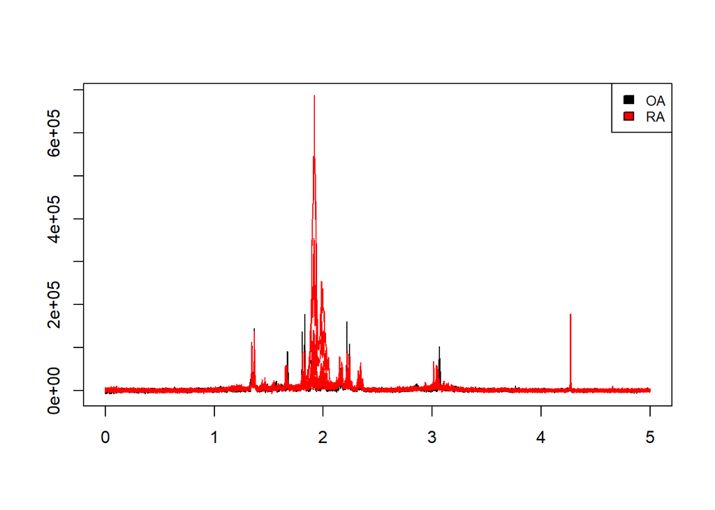

```r
MTBLS564_mv=missingvalues_imputation(MTBLS564_bruker, method = "value", value = 0.000001)

plot_spectra(MTBLS564_mv, "Diagnosis", variable.bounds=c(0,5))
```

```r
MTBLS564_peaks = detect_nmr_peaks_from_dataset(MTBLS564_mv, baseline_tresh = 50000)
```

```
## Spectrum  1  has  25  peaks.
## Spectrum  2  has  17  peaks.
## Spectrum  3  has  24  peaks.
## Spectrum  4  has  20  peaks.
## Spectrum  5  has  15  peaks.
## Spectrum  6  has  23  peaks.
## Spectrum  7  has  23  peaks.
## Spectrum  8  has  13  peaks.
## Spectrum  9  has  24  peaks.
## Spectrum  10  has  18  peaks.
## Spectrum  11  has  30  peaks.
## Spectrum  12  has  28  peaks.
## Spectrum  13  has  13  peaks.
## Spectrum  14  has  25  peaks.
## Spectrum  15  has  35  peaks.
## Spectrum  16  has  23  peaks.
## Spectrum  17  has  33  peaks.
## Spectrum  18  has  19  peaks.
## Spectrum  19  has  23  peaks.
## Spectrum  20  has  25  peaks.
## Spectrum  21  has  22  peaks.
## Spectrum  22  has  30  peaks.
## Spectrum  23  has  27  peaks.
## Spectrum  24  has  34  peaks.
```

### 3.1.2 Picos de interesse:

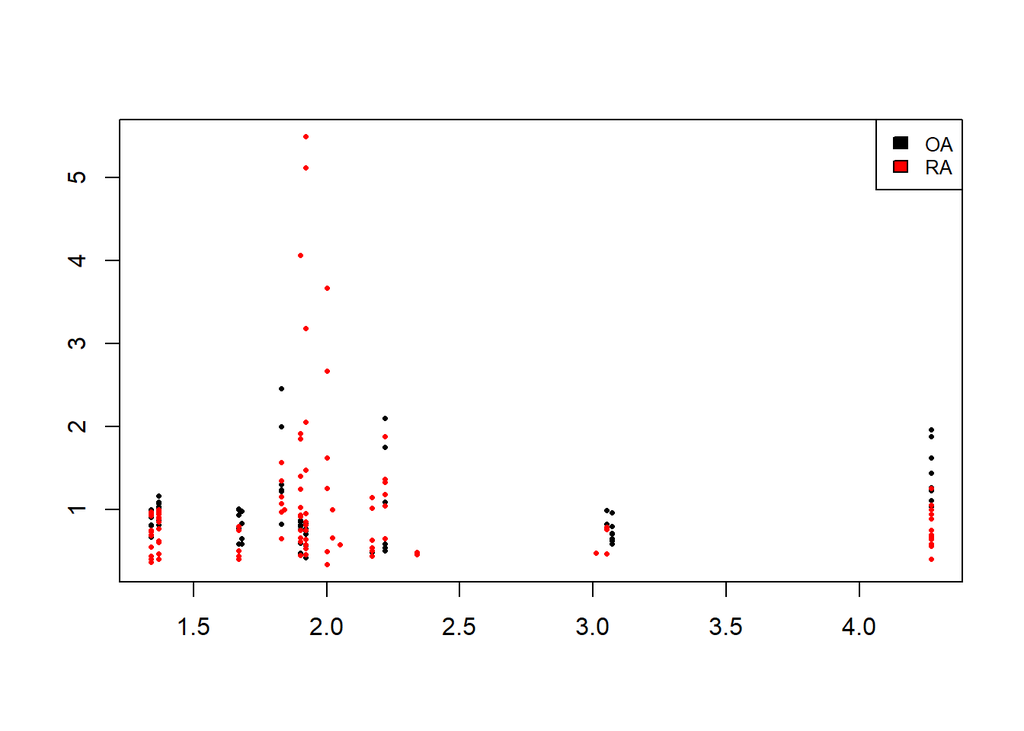

```r
MTBLS564_peaks_proc = normalize(MTBLS564_peaks, method = "median")
plot_peaks(MTBLS564_peaks_proc, "Diagnosis", variable.bounds=c(0,5))
```

### 3.1.5 Visualização dos dados dos metabolitos:

```r
sum_dataset(MTBLS564_data)
```

```
## Dataset summary:
## Valid dataset
## Description:  Metabolite profiling from MetaboLights study MTBLS564
## Type of data:  concentrations
## Number of samples:  24
## Number of data points 171
## Number of metadata variables:  1
## Label of x-axis values:  Metabolites
## Label of data points:  intensity
## Number of missing values in data:  0
## Mean of data values:  1.685489
## Median of data values:  1
## Standard deviation:  2.112825
## Range of values:  -0.08008629 26.92605
## Quantiles:
##          0%         25%         50%         75%        100%
## -0.08008629  0.36635624  1.00000000  2.00002118 26.92605056
```

```r
MTBLS564_data$data[1:6,1:6]
```

```
##                                 1         2         3         4         5
## mobile-lipid_1           3.686035 2.3457863 1.8983827 2.2996913 2.3323217
## 2-hydroxybutyrate_2      1.267497 0.7845856 0.8281637 0.9074245 0.8704131
## isoleucine_3             1.197878 1.0163177 1.0636870 0.9745458 0.9607551
## isoleucine/leucine_4     1.781404 1.8298738 1.8348756 1.6469039 1.4329635
## leucine_5                1.835512 2.0311221 1.9468557 1.8644277 1.4558589
## 2-aminobutyrate/valine_6 1.794456 1.9091548 1.9053745 1.7859294 1.6601811
##                                 6
## mobile-lipid_1           3.293267
## 2-hydroxybutyrate_2      1.064063
## isoleucine_3             1.129816
## isoleucine/leucine_4     1.616184
## leucine_5                1.596997
## 2-aminobutyrate/valine_6 1.646831
```

```r
MTBLS564_data$metadata[1:6,]
```

```
## [1] OA OA OA OA OA OA
## Levels: OA RA
```

### 3.1.6 Organizar dados em subconjuntos(‘subset’) de acordo com a metadata

```r
MTBLS564_OA_RA=subset_samples_by_metadata_values(MTBLS564_data,"Diagnosis",c("OA", "RA"))
```

## 3.2 DESCRIPTIVE STATISTICS

### 3.2.2 T test

-Selecção de metabolitos com ‘p values’ significativos:

```r
#Metabolites that will remain:
metabolites = rownames(significant_MTBLS564)
```

- Remover dados não significativos do dataset

```r
#Taking the significant metabolites from the diagnosis aside:
MTBLS564_nrm_metabolites =  subset_x_values(MTBLS564_data, metabolites)

#Get a dataset with only the samples from OA and RA diagnosis:
MTBLS564_OA_RA_new = subset_samples_by_metadata_values(MTBLS564_nrm_metabolites, "Diagnosis", c("OA", "RA"))
```

- Remover samples desconhecidas

```r
#Remove unknown samples
significant_MTBLS564_known = subset_x_values(MTBLS564_OA_RA_new, grep(".*[U,u]nknown.*", rownames(MTBLS564_OA_RA_new$data), value=T, invert=T))
```

### 3.2.3 Analysis of significant metabolite data

- Teste t para metabolitos significativos e conhecidos:

```r
ttest_significant_MTBLS564_known = tTests_dataset(significant_MTBLS564_known, "Diagnosis")
```

- Gráfico do teste t (pvalues) com ‘threshold’ de 0.05:

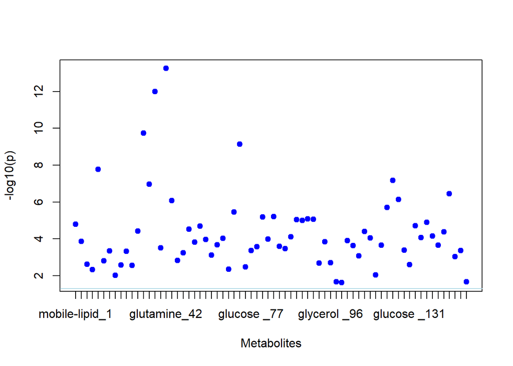

```r
plot_ttests(significant_MTBLS564_known, ttest_significant_MTBLS564_known, tt.threshold = 0.05)
```

### 3.2.4 Anova 1 way

```r
anova_res=aov_all_vars(significant_MTBLS564_known, "Diagnosis", doTukey = T, write.file = F, file.out = "anova-res.csv")
```

### 3.2.5 Plot of Anova

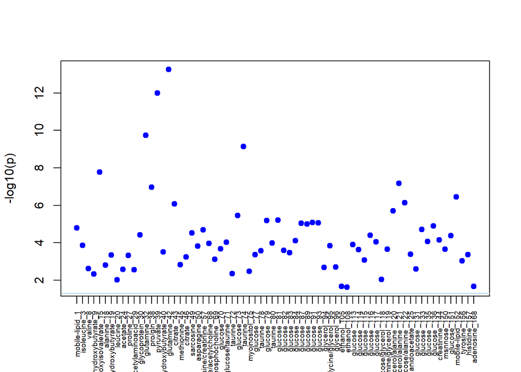

```r
plot_anova(significant_MTBLS564_known, anova_res, anova.threshold = 0.05, reverse.x = F)
```

```r
#confirms the significative results from the t test
```

### 3.2.6 Kruskal-Wallis test

```r
kruskal_res=kruskalTest_dataset(significant_MTBLS564_known, "Diagnosis", threshold = 0.01, write.file = F, file.out = "kruskal.csv")
```

### 3.2.7 Plot of Kruskal

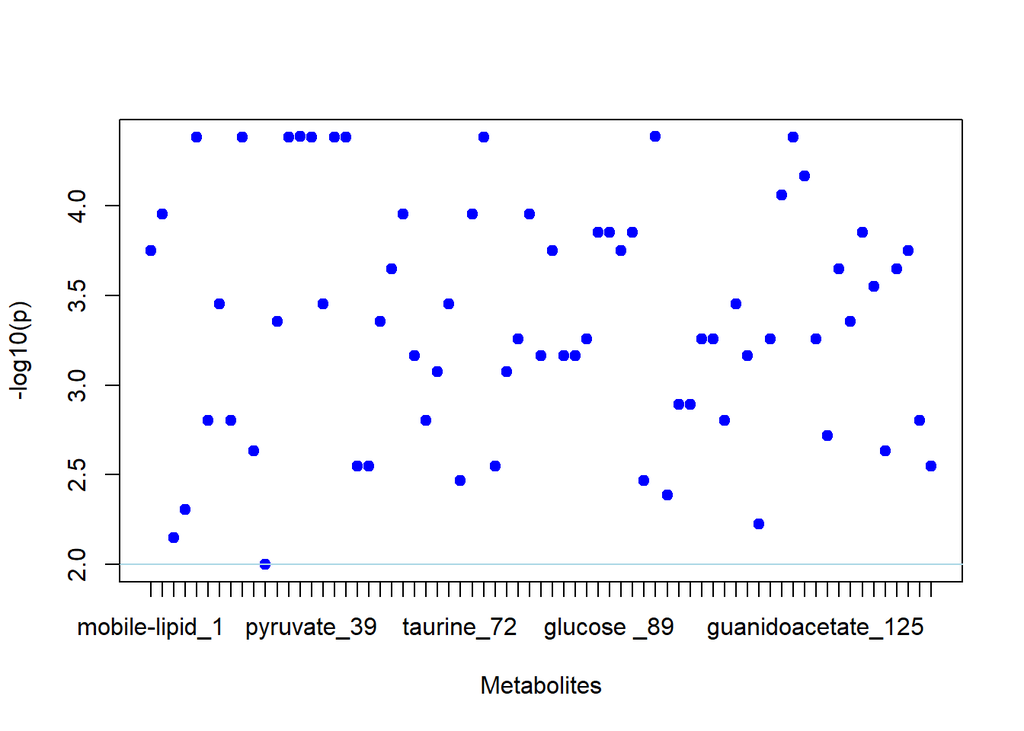

```r
plot_kruskaltest(significant_MTBLS564_known, kruskal_res, kr.threshold = 0.01)
```

## 3.3 DIFFERENTIAL EXPRESSION

- Plots seguintes, mostram a diferença entre os metabolitos de acordo com o diagnóstico

### 3.3.1 Boxplot de metabolitos significativos

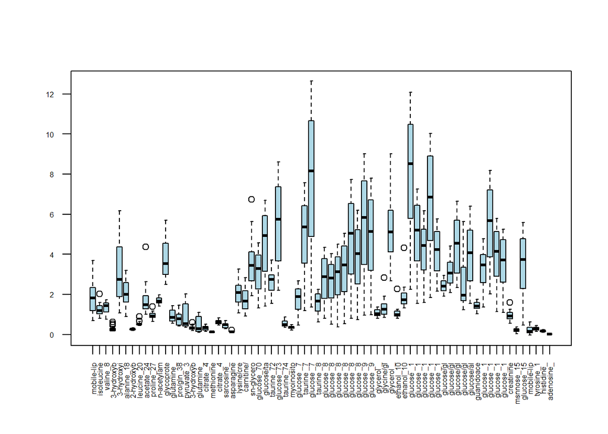

```r
#boxplot of significant metabolites
boxplot_variables(significant_MTBLS564_known, horizontal=F, nhar.label=100, cex.axis=0.5)
```

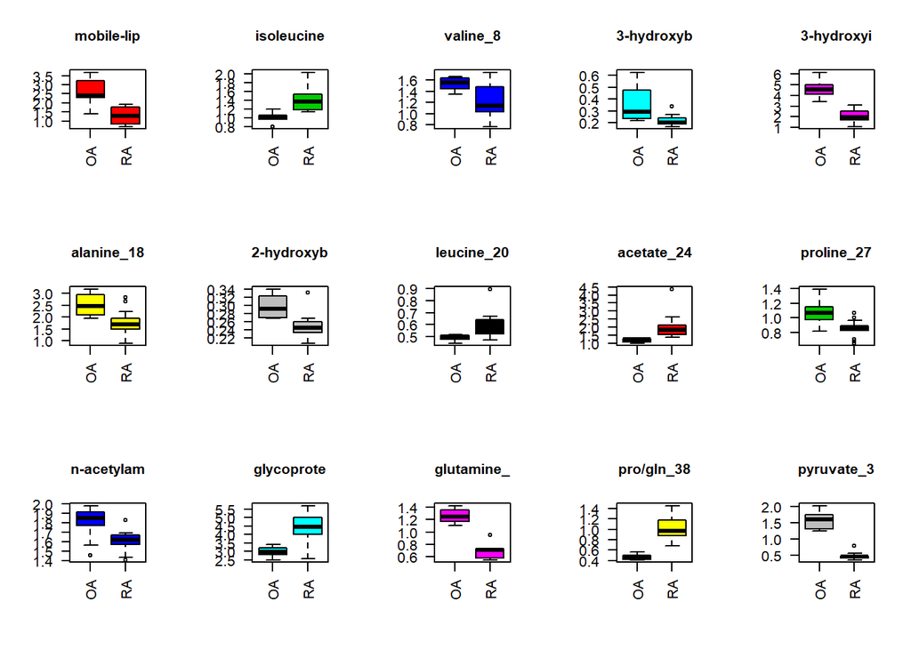

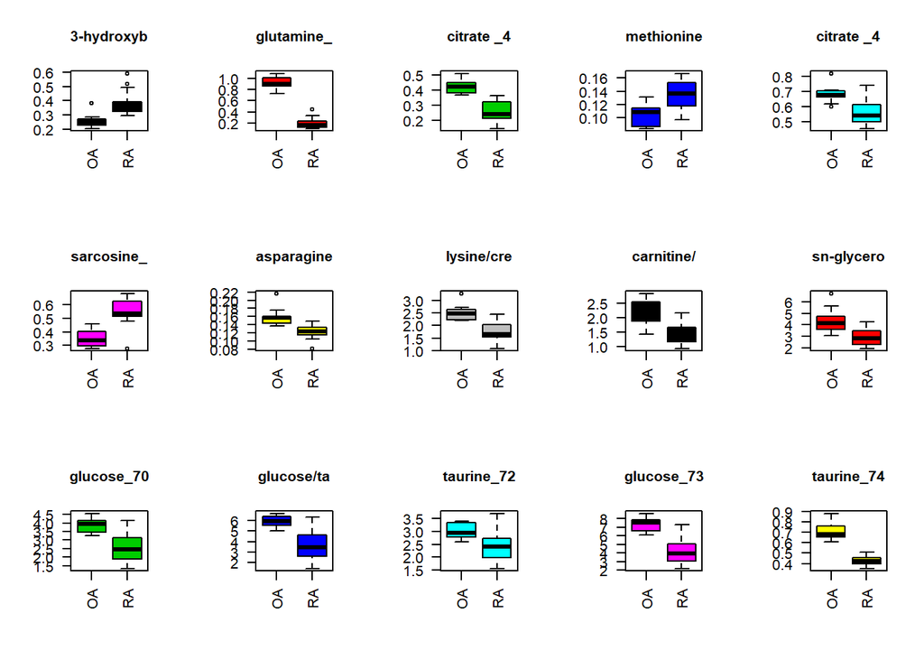

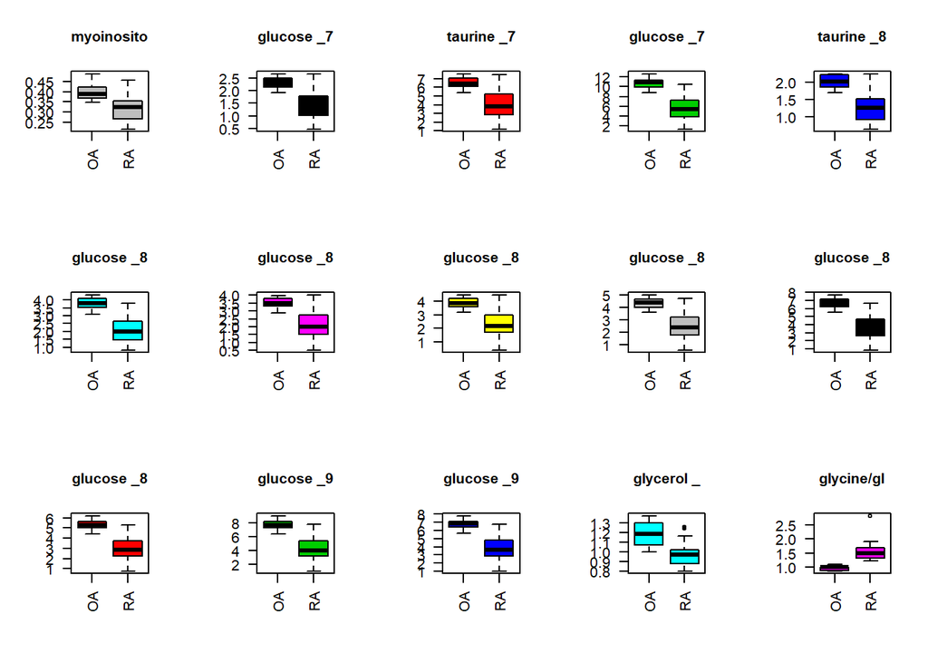

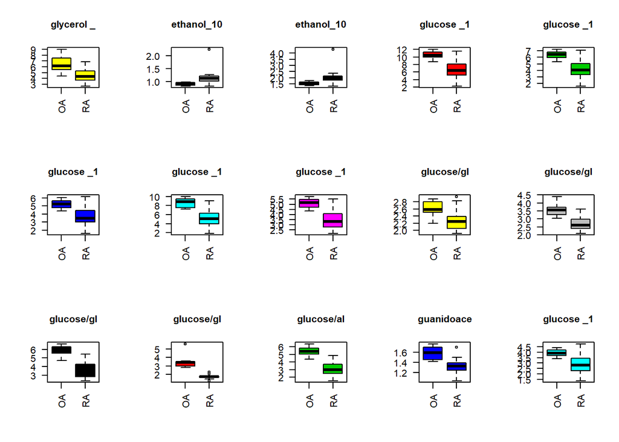

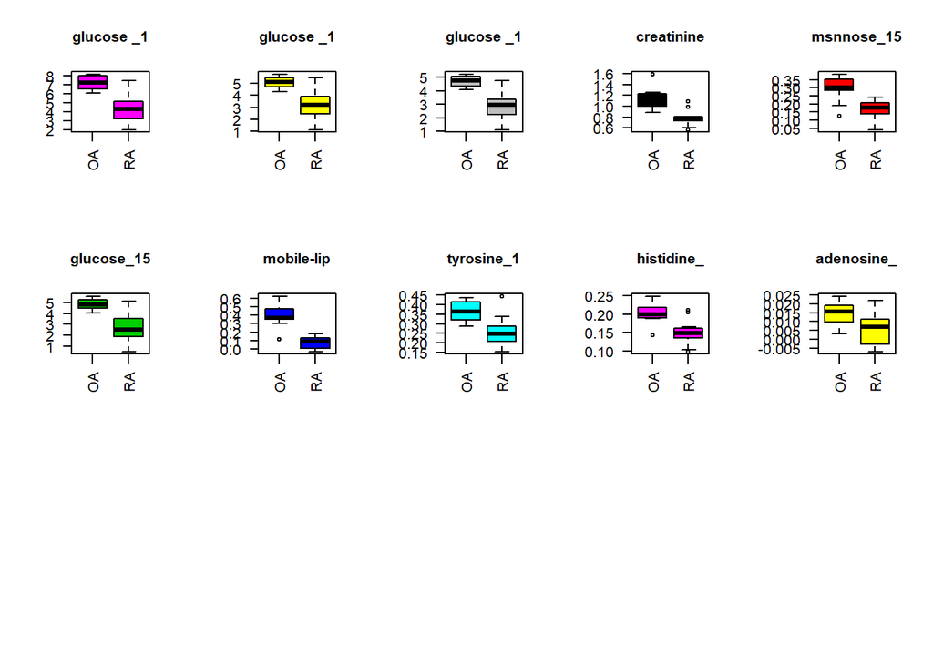

```r
boxplot_vars_factor(significant_MTBLS564_known, "Diagnosis", variables = row.names(significant_MTBLS564_known$data), cex.axis=1, cex.main=1, vec.par=c(3,5))
```

### 3.3.2 Fold change

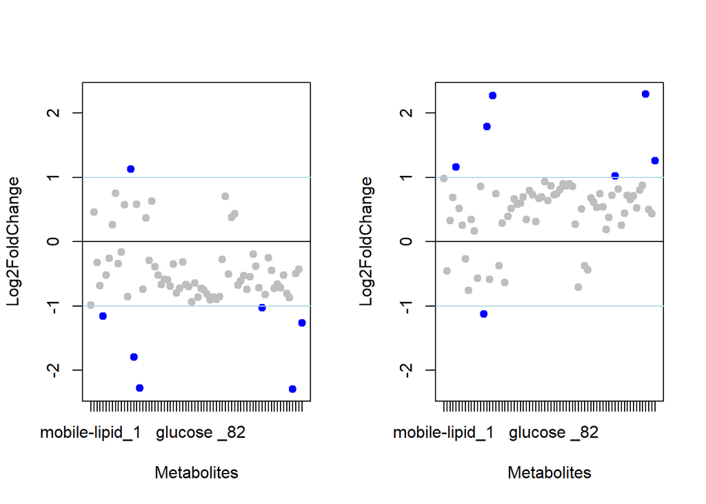

```r
fc_MTBLS564_OA_known = fold_change(significant_MTBLS564_known, "Diagnosis", "OA")
fc_MTBLS564_RA_known = fold_change(significant_MTBLS564_known, "Diagnosis", "RA")
#fold change plot
par(mfrow = c(1, 2))
plot_fold_change(significant_MTBLS564_known, na.omit(fc_MTBLS564_OA_known), 2)
plot_fold_change(significant_MTBLS564_known, na.omit(fc_MTBLS564_RA_known), 2)
```

```r
par(mfrow=c(1, 1))
```

### 3.3.3 Volcano plot

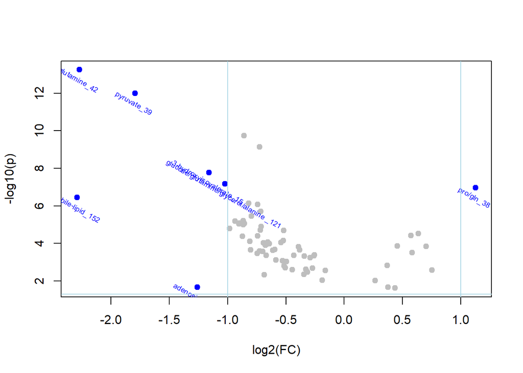

```
## [1] "3-hydroxyisovalerate_15"
## [2] "pro/gln_38"
## [3] "pyruvate_39"
## [4] "glutamine_42"
## [5] "glucose/glutamine/glycerol/alanine _121"
## [6] "mobile-lipid_152"
## [7] "adenosine_168"
```

```r
#volcano plot
volcano_plot_fc_tt(significant_MTBLS564_known, na.omit(fc_MTBLS564_OA_known), ttest_significant_MTBLS564_known[rownames(fc_MTBLS564_OA_known),], fc.threshold=2, tt.threshold = 0.05)
```

### 3.3.4 Heatmap

- Heatmap que mostra metabolitos significativamente diferentes em OA e RA SF (p < 0.05). Azul = baixo, branco = medio, vermelho = alta concentração.

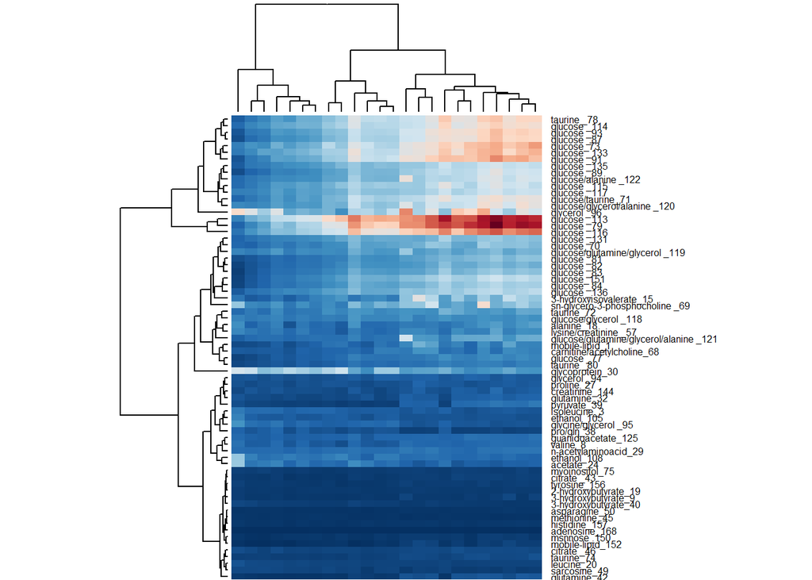

```r
colors = rev(colorRampPalette(RColorBrewer::brewer.pal(10,"RdBu"))(526))
stats::heatmap(significant_MTBLS564_known$data, scale="none", Colv=significant_MTBLS564_known$metadata$Diagnosis, margins=c(0,8), cexRow=0.6, cexCol=.4, keep.dendro=TRUE, col=colors, rownames(significant_MTBLS564_known$metadata$Diagnosis))
```

## 3.4 ENRIQUECIMENTO & PATHWAY ANALYSIS

- Ler nomes dos metabolitos e identificador do CHEBI a partir do dataset originail:

```r
signif_mets = row.names(significant_MTBLS564_known$data)
og_data = read.table('m_mtbls564_metabolite_profiling_NMR_spectroscopy_v2_maf.tsv', header=TRUE, sep='\t')
all_met_ids = og_data[c(1,5,7)]
ids = c()
met_names = c()
all_met_ids$database_identifier = as.character(all_met_ids$database_identifier)
all_met_ids$metabolite_identification = as.character(all_met_ids$metabolite_identification)
```

- Seleção dos nomes dos metabolitos e respectivos identificadores CHEBI a partir dos dados dos metabolitos significantes:

```r
for (i in 1:length(all_met_ids$pattern_ID)){
  if (is.element(all_met_ids$pattern_ID[i], signif_mets)==TRUE){ids[i]= all_met_ids$database_identifier[i];met_names[i]=all_met_ids$metabolite_identification[i]}}
```

- Exclusão de valores ‘NA’ e selecção dos identificadores CHEBI e nomes de metabolitos únicos:

```r
met_ids = na.omit(ids)
met_names = unique(met_names)
met_names = na.omit(met_names)
met_names = unique(met_names)
```

- Conversão dos indentificadores CHEBI para KEGG usando a ferramenta online MetaboAnalyst:

```r
met_db_ids = read.table('name_map.csv',header=TRUE,sep = ',')
View(met_db_ids)
met_kegg_id = data.frame(met_db_ids$KEGG)
met_kegg_id= met_kegg_id[!apply(met_kegg_id == "", 1, all),] #remove empty cells
```

- Criar base de dados para ‘Homo Sapiens’:

```r
fella.data
```

```
## General data:
## - KEGG graph:
##   * Nodes:  10953
##   * Edges:  33989
##   * Density:  0.0002833426
##   * Categories:
##     + pathway [322]
##     + module [117]
##     + enzyme [1134]
##     + reaction [5416]
##     + compound [3964]
##   * Size:  6.1 Mb
## - KEGG names are ready.
## -----------------------------
## Hypergeometric test:
## - Matrix not loaded.
## -----------------------------
## Heat diffusion:
## - Matrix is ready
##   * Dim:  10953 x 3964
##   * Size:  332.2 Mb
## - RowSums are ready.
## -----------------------------
## PageRank:
## - Matrix not loaded.
## - RowSums not loaded.
```

```r
cat(getInfo(fella.data))
```

```
## T01001           Homo sapiens (human) KEGG Genes Database
## hsa              Release 90.0+/06-01, Jun 19
##                  Kanehisa Laboratories
##                  38,744 entries
##
## linked db        pathway
##                  brite
##                  module
##                  ko
##                  genome
##                  enzyme
##                  network
##                  disease
##                  drug
##                  ncbi-geneid
##                  ncbi-proteinid
##                  uniprot
```

- Definir para compostos da analise identificadores KEGG dos metabolitos significativos presentes no SF:

```r
synovial_fluid_analysis = defineCompounds(compounds = as.character(met_kegg_id), data = fella.data)
```

```
## No background compounds specified. Default background will be used.
```

```r
getInput(synovial_fluid_analysis)
```

```
##  [1] "C00407" "C00183" "C01089" "C00041" "C00123" "C00033" "C00148"
##  [8] "C00064" "C00022" "C00158" "C00073" "C00213" "C00152" "C00047"
## [15] "C01996" "C00670" "C00031" "C00245" "C00137" "C00116" "C00037"
## [22] "C00469" "C00581" "C00791" "C00159" "C00082" "C00135" "C00212"
```

### 3.4.1 Enriquecimento

- Usamos o método de difusão:

```r
synovial_fluid_analysis = runDiffusion(object = synovial_fluid_analysis, data = fella.data, approx = "normality")
```

```
## Running diffusion...
```

```
## Computing p-scores through the specified distribution.
```

```
## Done.
```

```r
synovial_fluid_analysis
```

```
## Compounds in the input: 28
##  [1] "C00407" "C00183" "C01089" "C00041" "C00123" "C00033" "C00148"
##  [8] "C00064" "C00022" "C00158" "C00073" "C00213" "C00152" "C00047"
## [15] "C01996" "C00670" "C00031" "C00245" "C00137" "C00116" "C00037"
## [22] "C00469" "C00581" "C00791" "C00159" "C00082" "C00135" "C00212"
## Background compounds: all available compounds (default)
## -----------------------------
## Hypergeometric test: not performed
## -----------------------------
## Heat diffusion: ready.
## P-scores under 0.05:  362
## -----------------------------
## PageRank: not performed
```

### 3.4.2 Pathways Plot

- Resultados do enriquecimento

```
## 362 nodes below the threshold have been limited to 50 nodes.
```

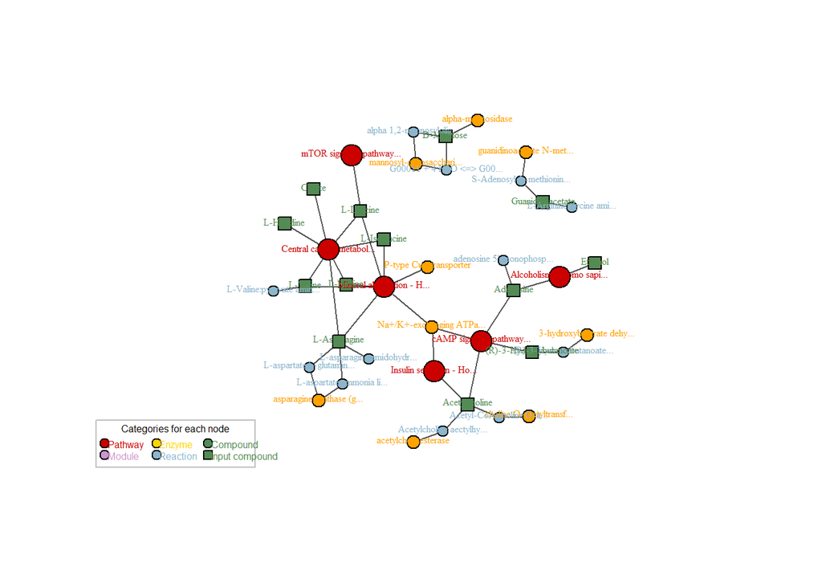

```r
nlimit <- 50
vertex.label.cex <- 0.5
plot(synovial_fluid_analysis, method = "diffusion", data = fella.data, nlimit = nlimit,vertex.label.cex = vertex.label.cex)
```

```r
table_all <- generateResultsTable( method = "diffusion", nlimit = 100, object = synovial_fluid_analysis, data = fella.data)
```

```
## Writing diffusion results...
```

```
## Done.
```

## 3.5 CONCLUSÃO - FASE 1

- Neste estudo foram observados maiores níveis de metabolismo anaeróbico em articulações de pacientes com RA do que com OA devido à diminuição de substratos para a glicólise e para o ciclo TCA, e da razão entre glucose e lactato em pacientes com RA. Nestes pacientes, os níveis de substratos para glicólise, como a glucose, alanina, glutamina e tirosina, aumentam aquando uma boa resposta ao tratamento por etanercept, sugerindo que os níveis destes metabolitos aumentam com a diminuição da inflamação [6]. Estes níveis de glucose podem ser explicados pelo metabolismo de fibroblastos residentes no SF e de células imunológicas que surgem em resposta à inflamação, particularmente neutrófilos [7], visto que estas células dependem somente da glicólise para produção de energia [8].
- Além disso, a falta de glucose pode explicar o aumento da atividade cetónica em pacientes de RA, por usa vez sinalizada pelo aumento de isoleucina, leucina e treonina no SF.
- 3-Hidroxibutirato é um metabolito característico da atividade cetónica e foi encontrado em maiores concentrações em SF de pacientes com RA comparativamente a controlos saudáveis em estudos anteriores [6]. Ao mesmo tempo, em concordância com a literatura onde os níveis de 3-hidroxibutirato diminuem em pacientes com RA quando em tratamento com entanercept, foram observadas concentrações deste metabolito significativamente menores em SF de pacientes com RA do que com OA [6].
- A diminuição de lípidos em SF de RA foi estudada anteriormente [9], sendo explicada pelo uso dos mesmos como fonte de energia nas articulações com hipoxia.
- A taurina é característica da patogénese de esclerose óssea subcondral [10], uma feição presente em ambos os casos de OA e RA [11]. Os níveis de taurina observados neste estudo apresentaram maiores valores em SF de OA do que RA. Isto pode dever-se a uma maior esclerose em pacientes com OA, e ao mesmo tempo servir como indicador do nível a que se encontra a patologia.

# 4 FASE 2

## 4.1 REDUÇÃO DA DIMENSIONALIDADE

-Dado um conjunto alargado de variáveis, descobrir um conjunto mais pequeno de variáveis não correlacionadas entre si  
que explicam a maior parte da variabilidade dos dados usando a técnica de Análise de Componentes Principais (PCA) usando os dados significativos.

-Análises por PCA demonstraram separação entre OA e RA . Os resultados demonstram que os perfis metabólicos são mais variáveis em SF de pacientes com RA do que com OA. Uma análise supervisionada por PLS-DA separou com sucesso as amostras referentes a RA e OA.

```r
pca_mtbls564 = pca_analysis_dataset(significant_MTBLS564_known, scale =F, center = F, write.file = F, file.out = "pca") #usa-se dataset normalizado
```

### 4.1.1 Tabela de Importância

```r
res_imp_pca_concentrations=pca_importance(pca_mtbls564, pcs=1:6) #coluna ordernadas por ordem decrescente dos valores de desvio padrão
DT::datatable(res_imp_pca_concentrations, options=list(scrollX=T))
```

|  | PC1 | PC2 | PC3 | PC4 | PC5 | PC6 |
| --- | --- | --- | --- | --- | --- | --- |
| Standard deviation | 28.352721521091 | 3.57901551373414 | 1.83131413542851 | 1.1942634810142 | 0.876057448195481 | 0.764975813434958 |
| Proportion of Variance | 0.97557 | 0.01555 | 0.00407 | 0.00173 | 0.00093 | 0.00071 |
| Cumulative Proportion | 0.97557 | 0.99112 | 0.99519 | 0.99692 | 0.99785 | 0.99856 |

### 4.1.2 Gráfico que mostra resultados em todos os PCs

- Cada ‘principal component’(PC) é gerada de forma a explicar o máximo de  
  variabilidade da parte ainda não explicada.
- A PCA é sensível à escala dos dados, e por isso usam-se os dados normalizados

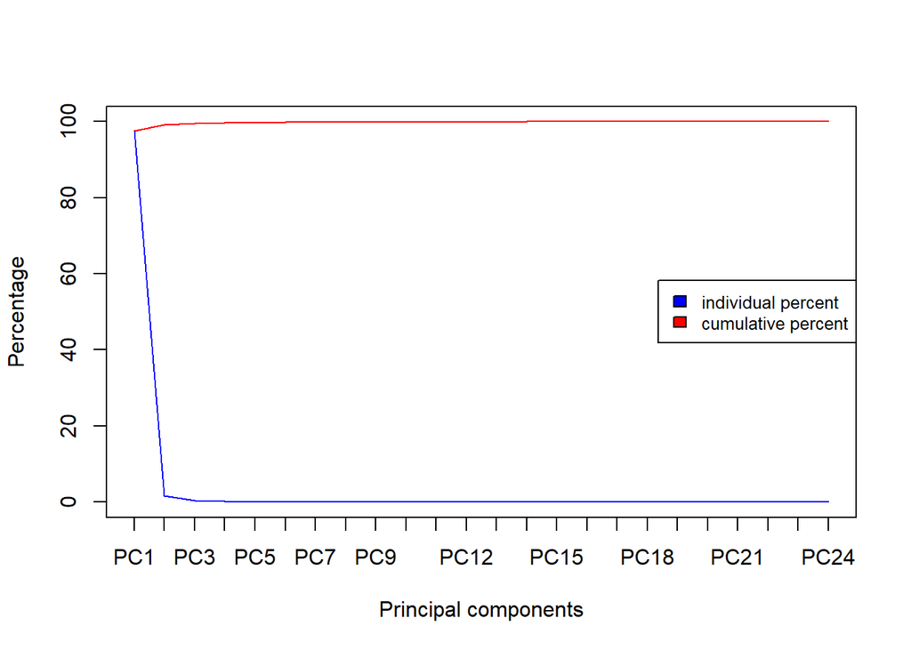

```r
pca_screeplot(pca_mtbls564)
```

- ‘Elbow method’

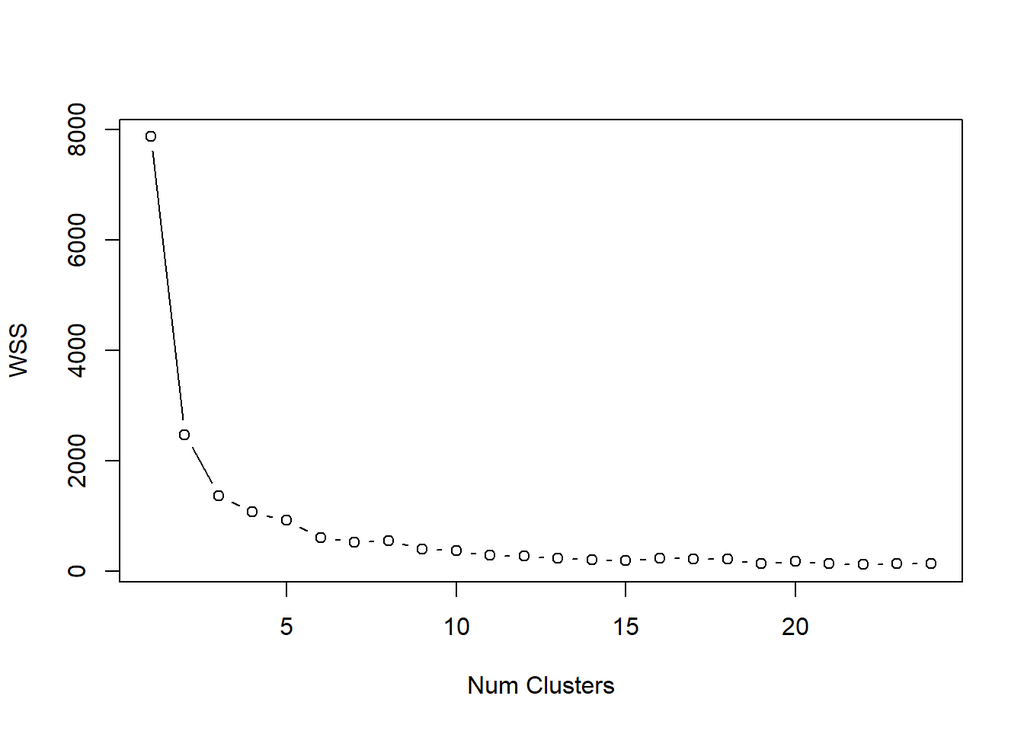

```r
wss = c()
for (k in 1:24) wss = c(wss, sum(kmeans(significant_MTBLS564_known$data, centers=k)$withinss) )
plot(1:24, wss, type="b", xlab="Num Clusters", ylab="WSS")
```

### 4.1.3 Scores Plot

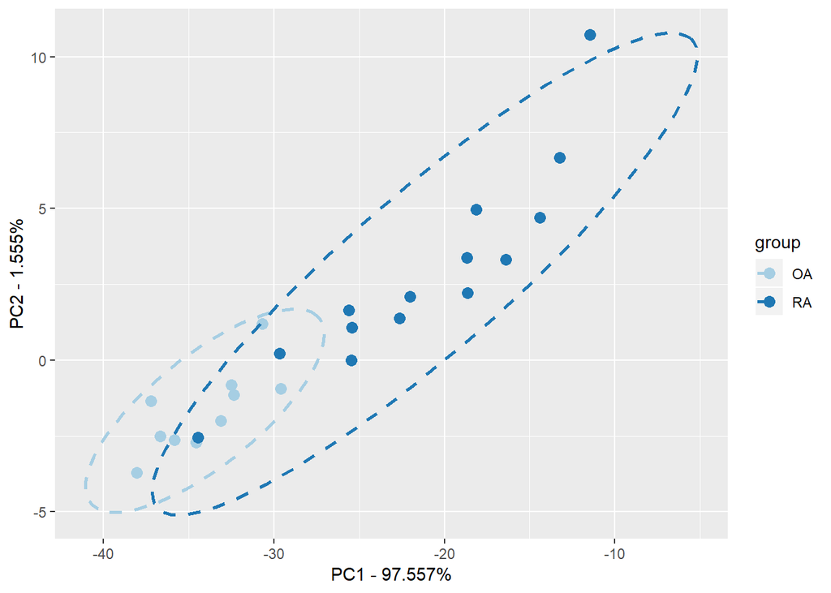

```r
#RColorBrewer::display.brewer.all()
pca_scoresplot2D(significant_MTBLS564_known, pca_mtbls564, "Diagnosis", pcas = c(1,2), ellipses = TRUE, pallette = "Paired")
```

```r
#pca_scoresplot3D(significant_MTBLS564_known, pca_mtbls564, "Diagnosis", pcas = c(1,2,3))
```

### 4.1.4 Pairs Plot

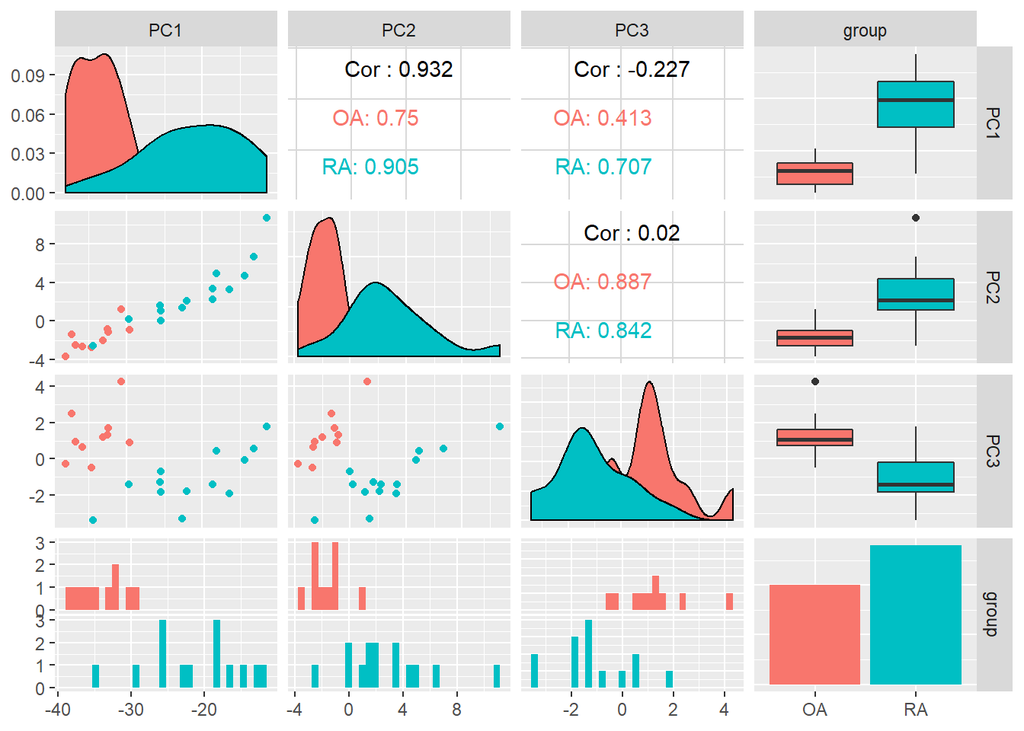

```r
pca_pairs_plot(significant_MTBLS564_known, pca_mtbls564, "Diagnosis", pcas = c(1,2,3))
```

### 4.1.5 Kmeans Plot

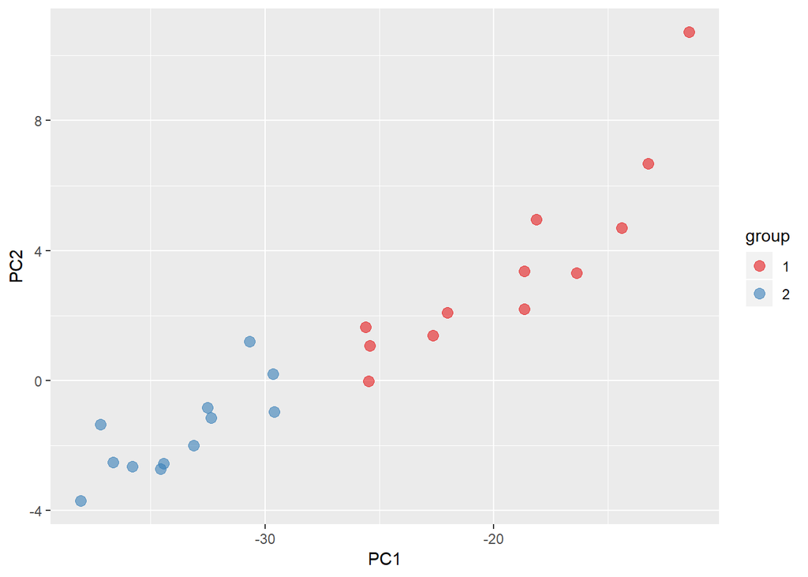

```r
pca_kmeans_plot2D(significant_MTBLS564_known, pca_mtbls564, num.clusters = 2)
```

```r
pca_kmeans_plot3D(significant_MTBLS564_known, pca_mtbls564, num.clusters = 2, pcas = c(1,2,3))
```

### 4.1.6 Kmeans Pairs Plot

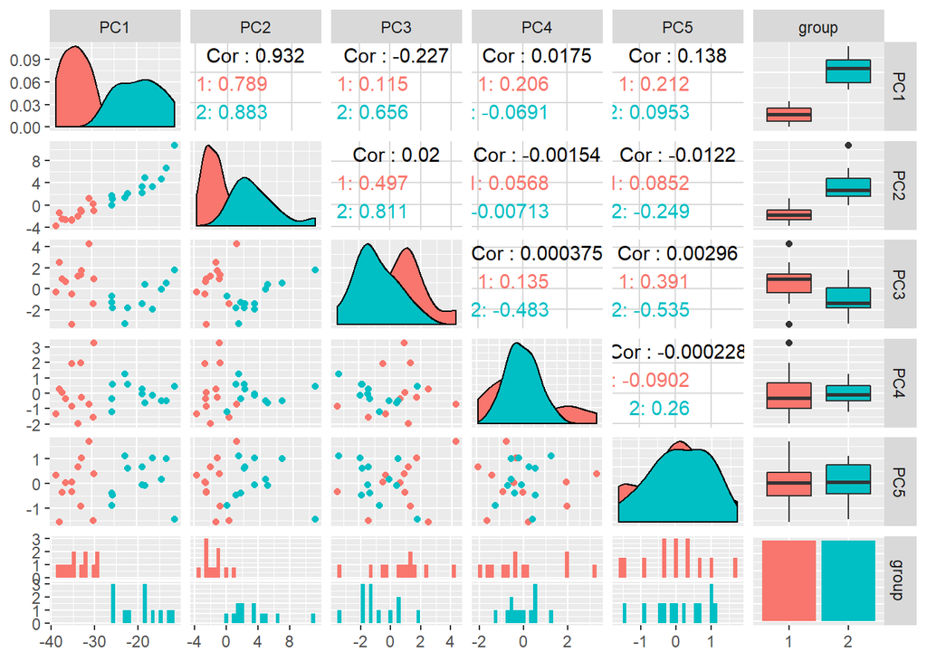

```r
pca_pairs_kmeans_plot(significant_MTBLS564_known, pca_mtbls564, num.clusters = 2, pcas = c(1,2,3,4,5))
```

## 4.2 CLUSTRERING

- Agrupamento dos dados de acordo do com o seu grau de semelhança, neste caso, em relação ao tipo de diagnóstico, usando o método ‘Hierarchical Clustering’ e distância Euclidiana

```r
cluster_mtbls564 = clustering(significant_MTBLS564_known, method = "hc", distance = "euclidean", type = "samples", num.clusters = 5, clustMethod = "complete")
```

### 4.2.1 Dendogram

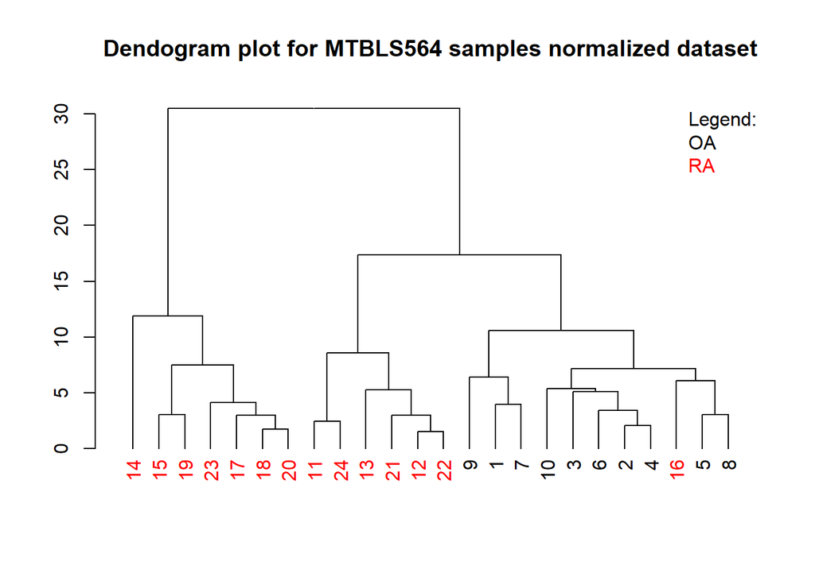

```r
dendrogram_plot_col(significant_MTBLS564_known, cluster_mtbls564, "Diagnosis", title = "Dendogram plot for MTBLS564 samples normalized dataset")
```

### 4.2.2 K-Means Clustering

```r
res_kclust_concentrations = clustering(significant_MTBLS564_known, method="kmeans", num.clusters=2)
```

### 4.2.3 K-means results plot

- Linhas a cinzento representam os valores das amostras desse cluster e a linha azul, a mediana dessas amostras:

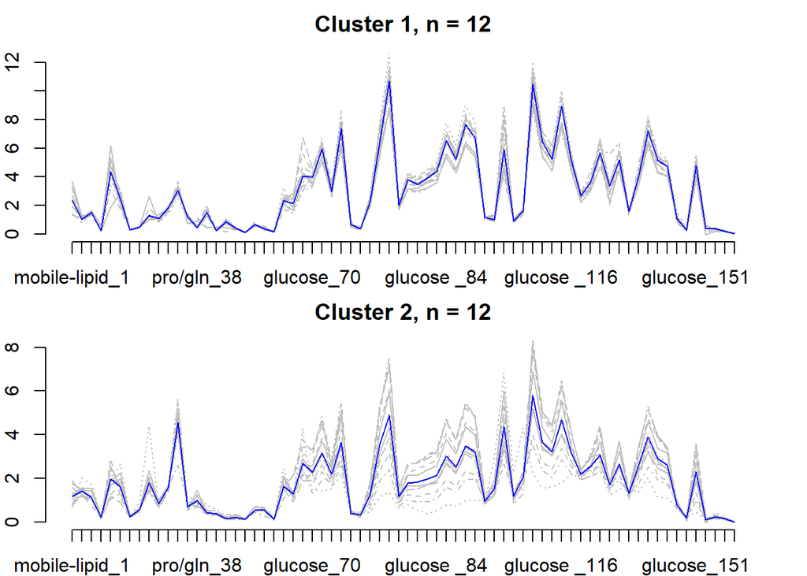

```r
kmeans_plot(significant_MTBLS564_known, res_kclust_concentrations)
```

# 5 FASE 3

## 5.1 MACHINE LEARNING

### 5.1.1 Análise Preditiva com Aprendizagem Máquina

```r
res_train_model$performance
```

```
##       Accuracy Kappa AccuracySD   KappaSD
## pls  1.0000000  1.00  0.0000000 0.0000000
## rf   0.9666667  0.94  0.1054093 0.1897367
## nnet 1.0000000  1.00  0.0000000 0.0000000
```

```r
#Partial Least Squares:
res_train_model$confusion.matrices$pls
```

```
## Cross-Validated (10 fold) Confusion Matrix
##
## (entries are percentual average cell counts across resamples)
##
##           Reference
## Prediction   OA   RA
##         OA 41.7  0.0
##         RA  0.0 58.3
##
##  Accuracy (average) : 1
```

```r
#Random Forests
res_train_model$confusion.matrices$rf
```

```
## Cross-Validated (10 fold) Confusion Matrix
##
## (entries are percentual average cell counts across resamples)
##
##           Reference
## Prediction   OA   RA
##         OA 41.7  4.2
##         RA  0.0 54.2
##
##  Accuracy (average) : 0.9583
```

```r
#Neural Network
res_train_model$confusion.matrices$nnet
```

```
## Cross-Validated (10 fold) Confusion Matrix
##
## (entries are percentual average cell counts across resamples)
##
##           Reference
## Prediction   OA   RA
##         OA 41.7  0.0
##         RA  0.0 58.3
##
##  Accuracy (average) : 1
```

-Teste do Modelo de Partial Least Squares (100% Accuracy) com Predict:

```r
res_predict_model_pls=predict_samples(res_train_model$final.models$pls, significant_MTBLS564_known$data)
res_predict_model_pls
```

```
##    sample predicted.class
## 1       1              OA
## 2       2              OA
## 3       3              OA
## 4       4              OA
## 5       5              OA
## 6       6              OA
## 7       7              OA
## 8       8              OA
## 9       9              OA
## 10     10              OA
## 11     11              RA
## 12     12              RA
## 13     13              RA
## 14     14              RA
## 15     15              RA
## 16     16              RA
## 17     17              RA
## 18     18              RA
## 19     19              RA
## 20     20              RA
## 21     21              RA
## 22     22              RA
## 23     23              RA
## 24     24              RA
```

```r
#res_predict_model_rf=predict_samples(res_train_model$final.models$rf, significant_MTBLS564_known$data)
#res_predict_model_nnet=predict_samples(res_train_model$final.models$nnet, #significant_MTBLS564_known$data)
```

### 5.1.2 Selecção de Metabolitos

-Segundo a verificação de importância das variáveis do modelo, os resultados estão apresentam consenso com o descrito pelos investigadores do artigo no qual o nosso trabalho se baseia [1]. Segundo os autores, as vias metabólicas que mais diferem entre as duas patologias são a glicólise, a biossíntese de aminoácidos e metabolismo de taurina e hipotaurina. É de esperar, portanto, que os metabolitos com maior importância estejam relacionados com estas vias.

-Verficar Importância dos metabolitos no diagnóstico usando a função varImp do Caret

```r
var_imp1 = varImp(res_train_model$final.models$rf)
importance = var_imp1[order(var_imp1$Overall, decreasing = T),c(0,1)]
var_imp_ord= as.data.frame(importance, row.names = rownames(var_imp1))
head(var_imp_ord,10)
```

```
##                          importance
## Xmobile_lipid_1           0.4451819
## Xisoleucine_3             0.3691426
## Xvaline_8                 0.3582393
## X3_hydroxybutyrate_9      0.3364170
## X3_hydroxyisovalerate_15  0.3356150
## Xalanine_18               0.3292918
## X2_hydroxybutyrate_19     0.3214056
## Xleucine_20               0.3009798
## Xacetate_24               0.2931771
## Xproline_27               0.2794306
```

```r
var_imp2 = varImp(res_train_model$final.models$rf)
importance = var_imp2[order(var_imp2$Overall, decreasing = T),c(0,1)]
var_imp2_ord= as.data.frame(importance, row.names = rownames(var_imp2))
head(var_imp2_ord,10)
```

```
##                          importance
## Xmobile_lipid_1           0.4451819
## Xisoleucine_3             0.3691426
## Xvaline_8                 0.3582393
## X3_hydroxybutyrate_9      0.3364170
## X3_hydroxyisovalerate_15  0.3356150
## Xalanine_18               0.3292918
## X2_hydroxybutyrate_19     0.3214056
## Xleucine_20               0.3009798
## Xacetate_24               0.2931771
## Xproline_27               0.2794306
```

```r
var_imp3 = varImp(res_train_model$final.models$nnet)
importance = var_imp3[order(var_imp3$Overall, decreasing = T),c(0,1)]
var_imp3_ord= as.data.frame(importance, row.names = rownames(var_imp1))
head(var_imp3_ord,10)
```

```
##                          importance
## Xmobile_lipid_1            6.567899
## Xisoleucine_3              5.573945
## Xvaline_8                  5.455261
## X3_hydroxybutyrate_9       4.351548
## X3_hydroxyisovalerate_15   4.086289
## Xalanine_18                3.774904
## X2_hydroxybutyrate_19      3.498364
## Xleucine_20                3.048844
## Xacetate_24                2.858671
## Xproline_27                2.748038
```

-Selecção de atributos (foi utilizada validação cruzada com 3 folds e repetida 5 vezes)

-Atributos seleccionados por este método quando fizemos o fit para uma árvore foram os seguintes:

```r
set.seed(115)
#res_train_model1=feature_selection(significant_MTBLS564_known, "Diagnosis", method="rfe", functions = caret::ldaFuncs, validation = "repeatedcv", number = 3, subsets = 2^(1:6))
#res_train_model1

res_train_model2=feature_selection(significant_MTBLS564_known, "Diagnosis", method="rfe", functions = caret::treebagFuncs, validation = "repeatedcv", number = 3, subsets = 2^(1:6))
res_train_model2 #resultados de fitting mais similares aos resultados de importância das variáveis do nosso modelo ao nosso modelo. O método é ideal para Regression e Classification models
```

```
##
## Recursive feature selection
##
## Outer resampling method: Cross-Validated (3 fold, repeated 5 times)
##
## Resampling performance over subset size:
##
##  Variables Accuracy  Kappa AccuracySD KappaSD Selected
##          2   0.9029 0.7949     0.1043  0.2179
##          4   0.9103 0.8096     0.1072  0.2242        *
##          8   0.9103 0.8096     0.1072  0.2242
##         16   0.9103 0.8096     0.1072  0.2242
##         32   0.9103 0.8096     0.1072  0.2242
##         64   0.9029 0.7949     0.1043  0.2179
##         70   0.8934 0.7770     0.1013  0.2110
##
## The top 4 variables (out of 4):
##    X3.hydroxyisovalerate_15, acetate_24, isoleucine_3, X2.hydroxybutyrate_19
```

```r
#res_train_model3=feature_selection(significant_MTBLS564_known, "Diagnosis", method="rfe", functions = caret::rfFuncs, validation = "repeatedcv", number = 3, subsets = 2^(1:6))
#res_train_model3
```

## 5.2 CONCLUSÃO - FASE 3

-Segundo os nossos resultados, a taurina e a hipotaurina, que caracterizam o nível de esclerose óssea presente em ambas as patologias, não atingiu o top 10 de importância dos metabolitos para classificar o diagnóstico. Em estudos prévios foram encontrados níveis de taurina maiores em RA do que em amostras controlo e do que em pacientes com OA. Apesar disso, o resultado da experiência realizada pelos autores demonstrou maiores níveis destes dois metabolitos em pacientes com OA. Talvez devido a esta ambiguidade, a taurina e hipotaurina possam não apresentar capacidade para distinguir o diagnostico entre as duas patologias em questão, segundo os resultados que obtivemos. Sendo assim, apesar de não serem um bom indicador da patologia, após esta ser diagnosticada serão talvez um bom indicador do estágio da mesma.

# 6 REFERÊNCIAS

1. Anderson, J. R. et al. 1H NMR Metabolomics Identifies Underlying Inflammatory Pathology in Osteoarthritis and Rheumatoid Arthritis Synovial Joints. Journal of Proteome Research 17, 3780–3790 (2018).
2. Anderson, J. R., Phelan, M. M., Clegg, P. D., Peffers, M. J. & Rubio-Martinez, L. M. Synovial Fluid Metabolites Differentiate between Septic and Nonseptic Joint Pathologies. Journal of Proteome Research 17, 2735–2743 (2018).
3. Costa, C., Maraschin, M. & Rocha, M. An R package for the integrated analysis of metabolomics and spectral data. Computer Methods and Programs in Biomedicine 129, 117–124 (2016).
4. Picart-Armada, S., Fernández-Albert, F., Vinaixa, M., Yanes, O. & Perera-Lluna, A. FELLA: An R package to enrich metabolomics data. BMC Bioinformatics 19, (2018).
5. Xia, J. & Wishart, D. S. Using metaboanalyst 3.0 for comprehensive metabolomics data analysis. Current Protocols in Bioinformatics 2016, 14.10.1-14.10.91 (2016).
6. Priori, R. et al. 1H-NMR-based metabolomic study for identifying serum profiles associated with the response to etanercept in patients with rheumatoid arthritis. PLoS ONE 10, (2015).
7. Wright, H. L., Moots, R. J. & Edwards, S. W. The multifactorial role of neutrophils in rheumatoid arthritis. Nature Reviews Rheumatology 10, 593–601 (2014).
8. Kramer, P. A., Ravi, S., Chacko, B., Johnson, M. S. & Darley-Usmar, V. M. A review of the mitochondrial and glycolytic metabolism in human platelets and leukocytes: Implications for their use as bioenergetic biomarkers. Redox Biology 2, 206–210 (2014).
9. Young, S. P. et al. The impact of inflammation on metabolomic profiles in patients with arthritis. Arthritis and Rheumatism 65, 2015–2023 (2013).
10. Yang, G. et al. Metabolic analysis of osteoarthritis subchondral bone based on UPLC/Q-TOF-MS. Analytical and Bioanalytical Chemistry 408, 4275–4286 (2016).
11. Li, G. et al. Identical subchondral bone microarchitecture pattern with increasedbone resorption in rheumatoid arthritis as comparedtoosteoarthritis. Osteoarthritis and Cartilage 22, 2083–2092 (2014).